# Concentraciones normalizadas NO2 & PM2.5 & PM10

Para poder hacer correr el código se necesita tener instaladas las librerias.

```python
!pip install shapely
!pip install pyproj

import pandas as pd
from shapely import wkt
from pyproj import Transformer
from shapely.ops import transform
import matplotlib.pyplot as plt
from mpl_toolkits.mplot3d import Axes3D
import re
import numpy as np
from sklearn.preprocessing import MinMaxScaler
```

# Cargar datos de contaminantes

Leer los datos de tres contaminantes (NO2, PM2.5 y PM10) desde archivos CSV, datos de 2022.

```python
# Cargar los archivos CSV para NO2, PM2.5 y PM10
df_no2 = pd.read_csv("./dat/2022_no2.csv")
df_pm25 = pd.read_csv("./dat/2022_pm2-5.csv")
df_pm10 = pd.read_csv("./dat/2022_pm10.csv")
```

Combinarlos en un único dataframe, utilizando las columnas comunes TRAM (identificador) y GEOM_WKT (geometría). Son comunes en los tres archivos.

```python
# Unir los dataframes df_no2 y df_pm25 por 'TRAM' y 'GEOM_WKT'
df_combined = pd.merge(df_no2, df_pm25, on=['TRAM', 'GEOM_WKT'], suffixes=('_no2', '_pm25'))

# Unir el dataframe combinado con df_pm10 por 'TRAM' y 'GEOM_WKT'
df_combined = pd.merge(df_combined, df_pm10, on=['TRAM', 'GEOM_WKT'], suffixes=('', '_pm10'))

# Mostrar el dataframe combinado
df_combined
```

|  | TRAM | Rang_no2 | GEOM_WKT | Rang_pm25 | Rang |
| --- | --- | --- | --- | --- | --- |
| 0 | T04719W | 20-30 µg/m³ | MultiLineString ((430229.78859372 4586585.1990... | 10-15 µg/m³ | 25-30 µg/m³ |
| 1 | T19941Z | 20-30 µg/m³ | MultiLineString ((432928.8982969 4584019.98762... | 15-20 µg/m³ | 25-30 µg/m³ |
| 2 | T18111R | 20-30 µg/m³ | MultiLineString ((429953.2631029 4588161.44067... | 10-15 µg/m³ | 20-25 µg/m³ |
| 3 | T03222Y | 20-30 µg/m³ | MultiLineString ((427949.03825066 4580946.0427... | 10-15 µg/m³ | 20-25 µg/m³ |
| 4 | T17625I | 30-40 µg/m³ | MultiLineString ((433950.18894352 4585741.2135... | 15-20 µg/m³ | 25-30 µg/m³ |
| ... | ... | ... | ... | ... | ... |
| 15036 | T17103N | 30-40 µg/m³ | MultiLineString ((428029.87900434 4581292.3456... | 10-15 µg/m³ | 20-25 µg/m³ |
| 15037 | T07428A | 30-40 µg/m³ | MultiLineString ((427903.28287694 4582223.1150... | 10-15 µg/m³ | 20-25 µg/m³ |
| 15038 | T02455J | 30-40 µg/m³ | MultiLineString ((428305.43989139 4581748.2282... | 10-15 µg/m³ | 20-25 µg/m³ |
| 15039 | T08868Y | 20-30 µg/m³ | MultiLineString ((431756.99914925 4585026.4560... | 10-15 µg/m³ | 20-25 µg/m³ |
| 15040 | T05105C | 20-30 µg/m³ | MultiLineString ((429744.79842737 4586398.0134... | 10-15 µg/m³ | 25-30 µg/m³ |

15041 rows × 5 columns

# Renombrar y reorganizar columnas

Hacer que el dataframe combinado sea más legible, reorganizando las columnas relevantes. Renombrar la columna Rang como Rang_pm10 para mantener consistencia, con las otras dos columnas. Reorganizar las columnas para que Rang_no2, Rang_pm25 y Rang_pm10 estén juntas.

```python
# Renombrar la columna 'Rang' a 'Rang_pm10'
df_combined.rename(columns={'Rang': 'Rang_pm10'}, inplace=True)

# Reordenar las columnas para que 'Rang_no2' esté al lado de 'Rang_pm25'
column_order = ['TRAM', 'GEOM_WKT', 'Rang_no2', 'Rang_pm25', 'Rang_pm10'] + [col for col in df_combined.columns if col not in ['TRAM', 'GEOM_WKT', 'Rang_no2', 'Rang_pm25', 'Rang_pm10']]
df_combined = df_combined[column_order]

# Mostrar el dataframe combinado
print(df_combined.head())
```

```
      TRAM                                           GEOM_WKT     Rang_no2  \
0  T04719W  MultiLineString ((430229.78859372 4586585.1990...  20-30 µg/m³
1  T19941Z  MultiLineString ((432928.8982969 4584019.98762...  20-30 µg/m³
2  T18111R  MultiLineString ((429953.2631029 4588161.44067...  20-30 µg/m³
3  T03222Y  MultiLineString ((427949.03825066 4580946.0427...  20-30 µg/m³
4  T17625I  MultiLineString ((433950.18894352 4585741.2135...  30-40 µg/m³

     Rang_pm25    Rang_pm10
0  10-15 µg/m³  25-30 µg/m³
1  15-20 µg/m³  25-30 µg/m³
2  10-15 µg/m³  20-25 µg/m³
3  10-15 µg/m³  20-25 µg/m³
4  15-20 µg/m³  25-30 µg/m³
```

# Calcular valores promedio de las concentraciones

Para poder realizar una representacion grafica convertimos los rangos (como "20-30 µg/m³") en valores numéricos promedio ("20-30 µg/m³" pasa a ser 25.0).

Se define una función obtener_valor_promedio que extrae los valores mínimos y máximos del rango, calcula el promedio, y devuelve el resultado.

Se aplica esta función a las columnas de rangos para calcular nuevas columnas (no2_promedio, pm25_promedio, pm10_promedio).

```python
# Función para obtener el valor promedio de un rango

def obtener_valor_promedio(rango):
    if isinstance(rango, str):  # Comprobamos si "rango == valores 'Rang_no2',etc..." es una cadena (string)
        try:
            valores = rango.split(' ')[0].split('-')

            # Separamos el rango numérico de la unidad (µg/m³)
            # Por ejemplo, "20-30 µg/m³",["20-30", "µg/m³"], volvemos ha hacer split [0] y se convierte en ['20', '30']
            # Calculamos el promedio de los dos valores

            promedio = (float(valores[0]) + float(valores[1])) / 2

            # Devolvemos el promedio

            return promedio
        except:
            return None  # Si algo sale mal, devolvemos None (en caso de que no se pueda extraer el valor)
    return None  # Si el rango no es una cadena, también devolvemos None


# Extraemos los valores promedio de los rangos

df_combined['no2_promedio'] = df_combined['Rang_no2'].apply(obtener_valor_promedio)
df_combined['pm25_promedio'] = df_combined['Rang_pm25'].apply(obtener_valor_promedio)
df_combined['pm10_promedio'] = df_combined['Rang_pm10'].apply(obtener_valor_promedio)
df_combined

# Para eliminar los warnings

import warnings
from pandas.errors import SettingWithCopyWarning

warnings.simplefilter(action='ignore', category=SettingWithCopyWarning)
```

# Convertir geometrías a objetos de Shapely

La función apply aplica la conversión wkt.loads a cada valor en la columna 'GEOM_WKT'. El resultado es una nueva columna llamada 'geometry' en el DataFrame, que contiene las geometrías convertidas a objetos Shapely.

```python
# Convertimos las geometrías de WKT a objetos Shapely
df_combined['geometry'] = df_combined['GEOM_WKT'].apply(wkt.loads)

# Extraemos las coordenadas de cada geometría (asumimos que son 'MultiLineString')
latitudes = []
longitudes = []
no2_values = []
pm25_values = []
pm10_values = []

# df_combined
# print(df_combined.dtypes)

# Geometry podria ser un objeto tipo 'Point', 'LineString', 'MultiLineString', el ultimo es nuestro caso.

# df_combined['tipo_geometria'] = df_combined['geometry'].apply(lambda x: x.geom_type)
# print(df_combined['tipo_geometria'].value_counts())
```

# Extraer coordenadas de las geometrías

Recorrer cada fila del DataFrame df_combined, y extraemos el valor de la columna "geometry", objeto tipo MulyiLineString. Los resultados se almacenan en las listas: latitudes, longitudes, no2_values, pm25_values, y pm10_values. Cada valor se añade a las respectivas listas para crear colecciones de datos estructurados.

```python
# Listas para coordenadas y valores
latitudes = []
longitudes = []
no2_values = []
pm25_values = []
pm10_values = []

# Recorremos las geometrías y agregamos las coordenadas y valores
for _, row in df_combined.iterrows():
    geom = row['geometry']
    no2 = row['no2_promedio']
    pm25 = row['pm25_promedio']
    pm10 = row['pm10_promedio']

    # Extraemos las coordenadas y asociamos valores
    if geom.geom_type == 'MultiLineString':
        for line in geom.geoms:
            for point in line.coords:
                latitudes.append(point[1])  # Latitud
                longitudes.append(point[0])  # Longitud
                no2_values.append(no2)  # NO2
                pm25_values.append(pm25)  # PM2.5
                pm10_values.append(pm10)  # PM10
    elif geom.geom_type == 'LineString':
        for point in geom.coords:
            latitudes.append(point[1])  # Latitud
            longitudes.append(point[0])  # Longitud
            no2_values.append(no2)  # NO2
            pm25_values.append(pm25)  # PM2.5
            pm10_values.append(pm10)  # PM10

# Verificamos que las dimensiones ahora coinciden
print(f"Dimensiones corregidas: Longitudes: {len(longitudes)}, Latitudes: {len(latitudes)}")
print(f"NO2: {len(no2_values)}, PM2.5: {len(pm25_values)}, PM10: {len(pm10_values)}")
```

```
Dimensiones corregidas: Longitudes: 52297, Latitudes: 52297
NO2: 52297, PM2.5: 52297, PM10: 52297
```

# Normalizar las concentraciones

Escalar las concentraciones a un rango entre 0 y 1 para facilitar la comparación.

Utilizo MinMaxScaler de sklearn para normalizar los valores de concentración (NO2, PM2.5 y PM10).

Aplicamos diferentes niveles para poder visulaizar las tres concentraciones y comparar visualmente y creamos una representacion gráfica

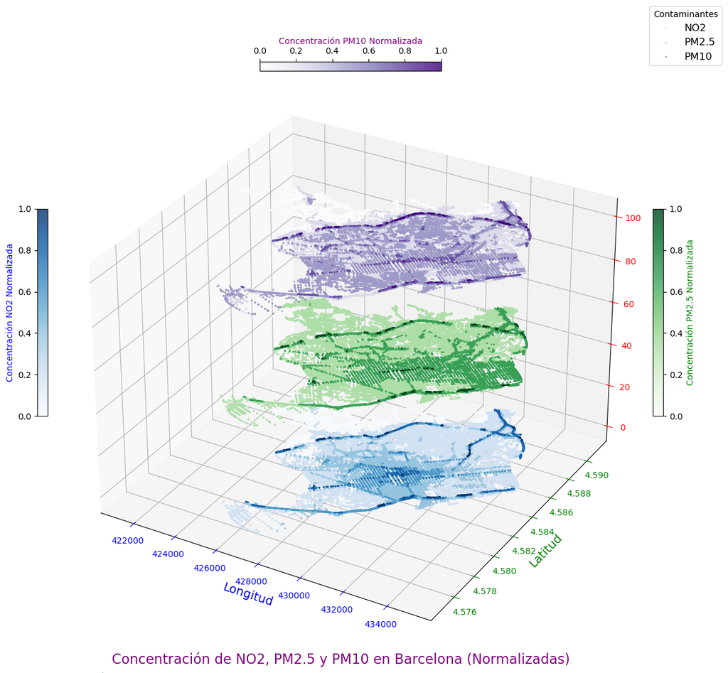

```python
# Normalizar las concentraciones usando Min-Max Scaler
scaler = MinMaxScaler()
no2_values_normalized = scaler.fit_transform(np.array(no2_values).reshape(-1, 1)).flatten()
pm25_values_normalized = scaler.fit_transform(np.array(pm25_values).reshape(-1, 1)).flatten()
pm10_values_normalized = scaler.fit_transform(np.array(pm10_values).reshape(-1, 1)).flatten()


# Configurar el tamaño del gráfico
fig = plt.figure(figsize=(14, 12))
ax = fig.add_subplot(111, projection='3d')

# Ajustar valores para diferenciar niveles en el eje Z
z_offset_no2 = 0
z_offset_pm25 = 50
z_offset_pm10 = 100

# Crear el gráfico de dispersión para NO2, PM2.5 y PM10
sc_no2 = ax.scatter(
    longitudes, latitudes, np.array(no2_values_normalized) + z_offset_no2,
    c=no2_values_normalized, cmap='Blues', s=2, label='NO2', alpha=0.8
)
sc_pm25 = ax.scatter(
    longitudes, latitudes, np.array(pm25_values_normalized) + z_offset_pm25,
    c=pm25_values_normalized, cmap='Greens', marker='^', s=2, label='PM2.5', alpha=0.8
)
sc_pm10 = ax.scatter(
    longitudes, latitudes, np.array(pm10_values_normalized) + z_offset_pm10,
    c=pm10_values_normalized, cmap='Purples', marker='x', s=2, label='PM10', alpha=0.8
)

# Etiquetas de los ejes
ax.set_xlabel('Longitud', fontsize=14, color='blue')
ax.set_ylabel('Latitud', fontsize=14, color='green')
ax.set_zlabel('', fontsize=14, color='red')

# Leyenda para identificar los contaminantes
ax.legend(loc='lower left', bbox_to_anchor=(1, 1), title='Contaminantes', fontsize=12)

# Ajuste de los ticks
ax.tick_params(axis='x', colors='blue', labelsize=10)
ax.tick_params(axis='y', colors='green', labelsize=10)
ax.tick_params(axis='z', colors='red', labelsize=10)

# Agregar barras de color individuales con colores claros a oscuros
cbar_no2 = fig.colorbar(sc_no2, ax=ax, shrink=0.3, pad=0, location='left')
cbar_no2.set_label('Concentración NO2 Normalizada', fontsize=10, color='blue')

cbar_pm25 = fig.colorbar(sc_pm25, ax=ax, shrink=0.3, pad=0, location='right')
cbar_pm25.set_label('Concentración PM2.5 Normalizada', fontsize=10, color='green')

cbar_pm10 = fig.colorbar(sc_pm10, ax=ax, shrink=0.3, pad=0, location='top')
cbar_pm10.set_label('Concentración PM10 Normalizada', fontsize=10, color='purple')

# Agregar el título debajo del gráfico
fig.suptitle('Concentración de NO2, PM2.5 y PM10 en Barcelona (Normalizadas)', fontsize=16, color='purple', y=0.02)

# Mostrar el gráfico
plt.tight_layout()
plt.show()
```

# Resultado

El gráfico final muestra las concentraciones normalizadas de los tres contaminantes en un espacio tridimensional:

Latitud y longitud representan la ubicación geográfica. Eje Z diferencia los contaminantes con un desplazamiento. Colores indican la intensidad de cada contaminante. Esta visualización permite identificar rápidamente zonas con mayores concentraciones de contaminantes y realizar comparaciones entre NO2, PM2.5 y PM10. En un principio el objetivo era realizar un modelo predictivo de urgencias por problemas respiratorios dependiendo de la zona donde se viva, pero no ha sido posible por falta de tiempo.

# Actualizacion niveles de contaminantes OMS

Podemos aprovechar el mismo codigo, sólo hemos de cambiar los valores de las condicionales:

##### NO2 de 40 (2005) a 10 (2021) µg/m³

##### PM2.5 de 10 (2005) a 5 (2021) µg/m³

##### PM10 de 20 (2005) a 15 (2021) µg/m³

# Gráfica datos 2022 según los niveles de la OMS de 2005

```python
# Calcular los colores según las condiciones

colors_no2 = ['red' if value > 40 else 'green' for value in no2_values]
colors_pm25 = ['orange' if value > 10 else 'blue' for value in pm25_values]
colors_pm10 = ['black' if value > 20 else 'gray' for value in pm10_values]

print(f"Dimensiones: Longitudes: {len(longitudes)}, Latitudes: {len(latitudes)}")
print(f"NO2: {len(no2_values)}, PM2.5: {len(pm25_values)}, PM10: {len(pm10_values)}")
print(f"Colores NO2: {len(colors_no2)}, Colores PM2.5: {len(colors_pm25)}, Colores PM10: {len(colors_pm10)}")
```

```
Dimensiones: Longitudes: 52297, Latitudes: 52297
NO2: 52297, PM2.5: 52297, PM10: 52297
Colores NO2: 52297, Colores PM2.5: 52297, Colores PM10: 52297
```

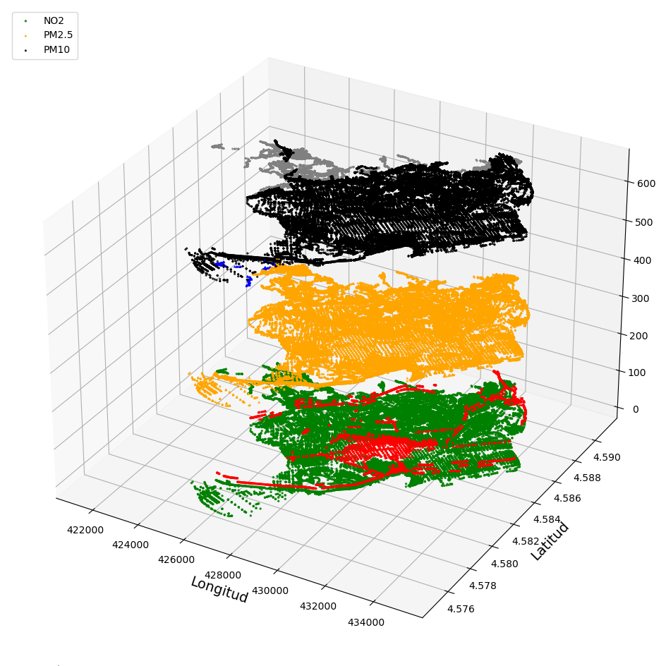

```python
# Configurar el tamaño del gráfico
fig = plt.figure(figsize=(14, 12))
ax = fig.add_subplot(111, projection='3d')

# Ajustar valores para diferenciar niveles en el eje Z, al no tenerlos normalizados el offset ha de ser mucho mayor.

z_offset_no2 = 0
z_offset_pm25 = 300
z_offset_pm10 = 600


# Crear el gráfico de dispersión para NO2, PM2.5 y PM10
sc_no2 = ax.scatter(
    longitudes, latitudes,
    np.array(no2_values) + z_offset_no2,  # Eje Z para NO2
    c=colors_no2, s=2, label='NO2', alpha=0.8
)
sc_pm25 = ax.scatter(
    longitudes, latitudes,
    np.array(pm25_values) + z_offset_pm25,  # Eje Z para PM2.5
    c=colors_pm25, marker='^', s=2, label='PM2.5', alpha=0.8
)
sc_pm10 = ax.scatter(
    longitudes, latitudes,
    np.array(pm10_values) + z_offset_pm10,  # Eje Z para PM10
    c=colors_pm10, marker='x', s=2, label='PM10', alpha=0.8
)

# Etiquetas de los ejes
ax.set_xlabel('Longitud', fontsize=14)
ax.set_ylabel('Latitud', fontsize=14)
ax.set_zlabel( ' ', fontsize=14)

# Leyenda
ax.legend(loc='upper left')

# Mostrar el gráfico

plt.show()
```

# Gráfica datos 2022 según los niveles de la OMS de 2021

```python
# Calcular los colores según las condiciones

colors_no2 = ['red' if value > 10 else 'green' for value in no2_values]
colors_pm25 = ['orange' if value > 5 else 'blue' for value in pm25_values]
colors_pm10 = ['black' if value > 15 else 'gray' for value in pm10_values]

print(f"Dimensiones: Longitudes: {len(longitudes)}, Latitudes: {len(latitudes)}")
print(f"NO2: {len(no2_values)}, PM2.5: {len(pm25_values)}, PM10: {len(pm10_values)}")
print(f"Colores NO2: {len(colors_no2)}, Colores PM2.5: {len(colors_pm25)}, Colores PM10: {len(colors_pm10)}")
```

```
Dimensiones: Longitudes: 52297, Latitudes: 52297
NO2: 52297, PM2.5: 52297, PM10: 52297
Colores NO2: 52297, Colores PM2.5: 52297, Colores PM10: 52297
```

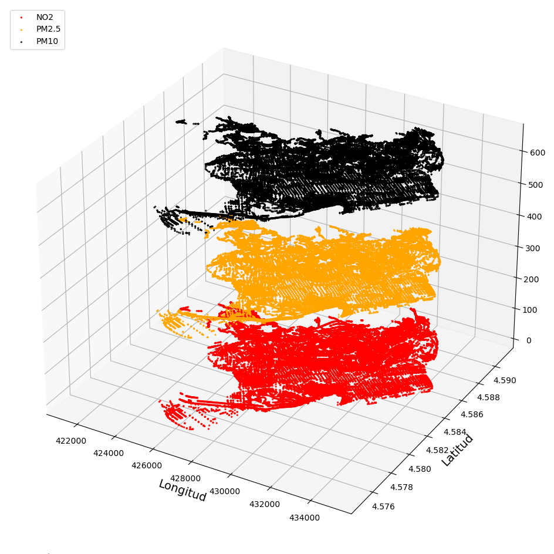

```python
# Configurar el tamaño del gráfico
fig = plt.figure(figsize=(14, 12))
ax = fig.add_subplot(111, projection='3d')

# Ajustar valores para diferenciar niveles en el eje Z, al no tenerlos normalizados el offset ha de ser mucho mayor.

z_offset_no2 = 0
z_offset_pm25 = 300
z_offset_pm10 = 600


# Crear el gráfico de dispersión para NO2, PM2.5 y PM10
sc_no2 = ax.scatter(
    longitudes, latitudes,
    np.array(no2_values) + z_offset_no2,  # Eje Z para NO2
    c=colors_no2, s=2, label='NO2', alpha=0.8
)
sc_pm25 = ax.scatter(
    longitudes, latitudes,
    np.array(pm25_values) + z_offset_pm25,  # Eje Z para PM2.5
    c=colors_pm25, marker='^', s=2, label='PM2.5', alpha=0.8
)
sc_pm10 = ax.scatter(
    longitudes, latitudes,
    np.array(pm10_values) + z_offset_pm10,  # Eje Z para PM10
    c=colors_pm10, marker='x', s=2, label='PM10', alpha=0.8
)

# Etiquetas de los ejes
ax.set_xlabel('Longitud', fontsize=14)
ax.set_ylabel('Latitud', fontsize=14)
ax.set_zlabel( ' ', fontsize=14)

# Leyenda
ax.legend(loc='upper left')

# Mostrar el gráfico

plt.show()
```

# Conclusiones

Es evidente que es necesario implementar medidas para mejorar las condiciones ambientales del aire en Barcelona.

Los datos indican que las rondas registran una mayor concentración de los tres contaminantes analizados.

Sería interesante profundizar en aspectos como el impacto de la altura en las mediciones, con el objetivo de evaluar la calidad de los datos, así como en la influencia de las condiciones ambientales, como la temperatura, el viento y la humedad, en los niveles de contaminación.

Además, resultaría muy interesante cruzar los datos obtenidos con información sobre urgencias cardiorrespiratorias y mortalidad atribuida a estas causas, para establecer posibles correlaciones y priorizar acciones preventivas.